# Preditores ambientais da comunidade zooplanctônica em riachos de floresta atlântica

# Referências

AGGIO, C. E. G. *et al.* The zooplankton of tropical streams: is it determinism or stochasticity that drives the spatial and temporal patterns in community structure? **Community Ecology**, Jul. 2022. v. 23, n. 2, p. 219–229. Disponível em: <https://link.springer.com/10.1007/s42974-022-00099-2>.

AMARAL, D. C.; BOMFIM, Francieli F.; LANSAC-TÔHA, Fábio A. Environmental heterogeneity drives the distribution of copepods (crustacea: Copepoda) in the amazon, araguaia, pantanal, and upper paraná floodplains. **Anais da Academia Brasileira de Ciências**, 2022. v. 94, n. 2, p. e20191260. Disponível em: <http://www.scielo.br/scielo.php?script=sci_arttext&pid=S0001-37652022000301009&tlng=en>.

ANDERSON, M. J. A new method for non-parametric multivariate analysis of variance. **Austral Ecology**, Feb. 2001. v. 26, n. 1, p. 32–46. Disponível em: <https://onlinelibrary.wiley.com/doi/10.1111/j.1442-9993.2001.01070.pp.x>.

ANDRIOTTI, J.; PETRUCIO, M. M.; SILVA, A. L. L. D. Exploring the impacts of non-native leaf litter on invertebrate community and leaf decomposition in a Atlantic Forest stream. **Acta Limnologica Brasiliensia**, 2022. v. 34, p. e17. Disponível em: <http://www.scielo.br/scielo.php?script=sci_arttext&pid=S2179-975X2022000100715&tlng=en>.

ARRUDA, D. B.; CUNHA, B. P.; RÊGO, K. M. C. Conflitos entre ReBio guaribas e comunidades locais: (in)justiça ambiental e ecologia política. **Revista Direitos Emergentes na Sociedade Global**, 2013. v. 2, n. 2.

BARBOZA, A. C. G.; TAGLIACOLLO, V.; JACOBUCCI, G. B. Influence of seasonal hydrological regimes on benthic macroinvertebrates in two the Brazilian biodiversity hotspots. **Limnologica**, May. 2024. v. 106, p. 126170. Disponível em: <https://linkinghub.elsevier.com/retrieve/pii/S0075951124000239>.

BARROS, L. De A. *et al.* No evidence of local deforestation leakage from protected areas establishment in Brazil’s Amazon and Atlantic Forest. **Biological Conservation**, Sep. 2022. v. 273, p. 109695. Disponível em: <https://linkinghub.elsevier.com/retrieve/pii/S0006320722002488>.

BEGA, J. M. M. *et al.* Effects of riparian vegetation restoration and environmental context on ecosystem functioning in tropical streams of southeastern Brazil. **Science of The Total Environment**, Oct. 2024. v. 948, p. 174906. Disponível em: <https://linkinghub.elsevier.com/retrieve/pii/S0048969724050563>.

BELTRÃO, G. D. B. M.; MEDEIROS, Elvio Sergio Figueredo; RAMOS, R. T. D. C. Effects of riparian vegetation on the structure of the marginal aquatic habitat and the associated fish assemblage in a tropical Brazilian reservoir. **Biota Neotropica**, Dec. 2009. v. 9, n. 4, p. 37–43. Disponível em: <http://www.scielo.br/scielo.php?script=sci_arttext&pid=S1676-06032009000400003&lng=en&tlng=en>.

BLANCHET, F. G.; LEGENDRE, Pierre; BORCARD, D. FORWARD SELECTION OF EXPLANATORY VARIABLES. **Ecology**, Sep. 2008. v. 89, n. 9, p. 2623–2632. Disponível em: <https://esajournals.onlinelibrary.wiley.com/doi/10.1890/07-0986.1>.

BOMFIM, Francieli F. *et al.* Warming alters the metabolic rates and life-history parameters of ceriodaphnia silvestrii (cladocera). **Anais da Academia Brasileira de Ciências**, 2022. v. 94, n. 2, p. e20200604. Disponível em: <http://www.scielo.br/scielo.php?script=sci_arttext&pid=S0001-37652022000301010&tlng=en>.

______ *et al.* How are zooplankton’s functional guilds influenced by land use in amazon streams? **PLOS ONE**, 1 Aug. 2023. v. 18, n. 8, p. e0288385. Disponível em: <https://doi.org/10.1371/journal.pone.0288385>.

______ *et al.* What do we know about zooplankton occurrence and distribution in Neotropical streams? A systematic review of published studies in Brazil. **Hydrobiologia**, Jun. 2024. v. 851, n. 11, p. 2561–2572. Disponível em: <https://link.springer.com/10.1007/s10750-024-05485-7>.

BOWEN, K. L. **Methods for the determination of zooplankton density, biomass and secondary production**. Burlington, ON: Fisheries; Oceans Canada, 2017.

BRASIL. Lei nº 9.985, de 18 de julho de 2000. 18 Jul. 2000. Disponível em: <https://planalto.gov.br/ccivil_03/leis/l9985.htm>.

CASTILHO-NOLL, M. S. M. *et al.* A review of 121 years of studies on the freshwater zooplankton of Brazil. **Limnologica**, May. 2023. v. 100, p. 126057. Disponível em: <https://linkinghub.elsevier.com/retrieve/pii/S0075951123000063>.

CHEN, H. *et al.* Review of the approaches for assessing protected areas’ effectiveness. **Environmental Impact Assessment Review**, Jan. 2023. v. 98, p. 106929. Disponível em: <https://linkinghub.elsevier.com/retrieve/pii/S0195925522001950>.

CLARKE, K. R. Non-parametric multivariate analyses of changes in community structure. **Australian Journal of Ecology**, Mar. 1993. v. 18, n. 1, p. 117–143. Disponível em: <https://onlinelibrary.wiley.com/doi/10.1111/j.1442-9993.1993.tb00438.x>.

COSTA, J. H. A. D. *et al.* Drivers of fish beta diversity vary by habitat and rainfall period in temporary freshwater habitats of the atlantic forest. **Frontiers in Freshwater Science**, 26 Mar. 2026. v. 4, p. 1776529. Disponível em: <https://www.frontiersin.org/articles/10.3389/ffwsc.2026.1776529/full>.

CREDIT. CRediT - contributor role taxonomy. **NISO/CRediT Standing Committee**, 2026. Disponível em: <https://credit.niso.org/>.

DUFRÊNE, M.; LEGENDRE, Pierre. SPECIES ASSEMBLAGES AND INDICATOR SPECIES:THE NEED FOR A FLEXIBLE ASYMMETRICAL APPROACH. **Ecological Monographs**, Aug. 1997. v. 67, n. 3, p. 345–366. Disponível em: <http://doi.wiley.com/10.1890/0012-9615(1997)067[0345:SAAIST]2.0.CO;2>.

EBLING, L. A.; PADIAL, A. A. THE CONNECTIONS BETWEEN RIPARIAN VEGETATION AND WATER QUALITY IN THE ATLANTIC FOREST. **Oecologia Australis**, 13 Dec. 2024. v. 28, n. 04, p. 256–271. Disponível em: <https://revistas.ufrj.br/index.php/oa/article/view/64328>.

ELMOOR-LOUREIRO, L. **Manual de identificação de cladóceros límnicos do brasil**. [S.l.]: [s.n.], 1997.

ESTEVES, F. De A. **Fundamentos de Limnologia**. 3. ed. Rio de Janeiro: Interciência, 2011.

FACHINELLI, N. P.; PEREIRA, A. O. Effects of Restoration and Conservation of Riparian Vegetation on Sediment Retention in the Catchment Area of Corumbá IV Hydroelectric Power Plant, Brazil. **World**, 26 Sep. 2023. v. 4, n. 4, p. 637–652. Disponível em: <https://www.mdpi.com/2673-4060/4/4/40>.

FARIA, H. H. D.; PIRES, A. S.; CURI, P. J. Temporal performance of the management effectiveness of a protected area in the brazilian atlantic forest, são paulo, brazil. **Periódico Eletrônico Fórum Ambiental da Alta Paulista**, 31 Dec. 2021. v. 17, n. 6. Disponível em: <https://publicacoes.amigosdanatureza.org.br/index.php/forum_ambiental/article/view/3076>.

FISHER, W. L. Stream ecology: Structure and function of running waters. **Transactions of the American Fisheries Society**, 1 Jan. 1996. v. 125, n. 1, p. 154–158. Disponível em: <https://doi.org/10.1577/1548-8659-125.1.154>.

FONSECA, G. A. B. The vanishing brazilian atlantic forest. **Biological Conservation**, 1 Jan. 1985. v. 34, n. 1, p. 17–34. Disponível em: <https://www.sciencedirect.com/science/article/pii/0006320785900552>.

GIONGO, M. L.; PETESSE, M. L.; ESTEVES, K. E. Fish responses to multiple scales in coastal blackwater atlantic forest streams in southeast brazil. **Neotropical Ichthyology**, 2023. v. 21, n. 2, p. e230030. Disponível em: <http://www.scielo.br/scielo.php?script=sci_arttext&pid=S1679-62252023000200218&tlng=en>.

GOMES, L. F. *et al.* Environmental and spatial influences on stream zooplankton communities of the Brazilian Cerrado. **Community Ecology**, Apr. 2020. v. 21, n. 1, p. 25–31. Disponível em: <http://link.springer.com/10.1007/s42974-020-00008-5>.

GOUVEIA, R. S. D. *et al.* Ichthyofauna of the Reserva Biológica Guaribas and surrounding areas, state of Paraíba, Brazil. **Check List**, 6 Oct. 2017. v. 13, n. 5, p. 581–590. Disponível em: <https://checklist.pensoft.net/articles.php?id=21379>.

GUTIERREZ, M. F. *et al.* Zooplankton shifts from headwater to lowland streams: Insights into the role of water quality to assist the protection and restoration of agricultural waterways. **Ecohydrology**, Jun. 2022. v. 15, n. 4, p. e2432. Disponível em: <https://onlinelibrary.wiley.com/doi/10.1002/eco.2432>.

HANEY, J. F.; HALL, D. J. Sugar-coated daphnia: A preservation technique for cladocera. **Limnology and Oceanography**, 1 Mar. 1973. v. 18, n. 2, p. 331–333. Disponível em: <https://doi.org/10.4319/lo.1973.18.2.0331>.

HEINRICHS, R. *et al.* [Importance of sugarcane in brazilian and world bioeconomy](https://doi.org/10.1007/978-3-319-58374-7_11). *In*: DABBERT, S. *et al.* (Eds.). Cham: Springer International Publishing, 2017, p. 205–217.

HEPP, Luiz Ubiratan *et al.* Agriculture affects functional diversity of aquatic insects in subtropical atlantic forest streams. **Acta Limnologica Brasiliensia**, 2023. v. 35, p. e31. Disponível em: <http://www.scielo.br/scielo.php?script=sci_arttext&pid=S2179-975X2023000100726&tlng=en>.

JOKO, C. Y. **Taxonomia de rotíferos monogonontas da planície de inundação do alto rio paraná (MS/PR)**. Maringá: [s.n.], 2011. PhD thesis.

KOSTE, W.; SHIEL, R. [Rotifera from australian inland waters. II. Epiphanidae and brachionidae (rotifera : monogononta)](https://doi.org/10.1071/IT9870949). **Invertebrate Systematics**, 1 Nov. 1987. v. 1, p. 949–1021.

LÊ, S.; JOSSE, J.; HUSSON, F. **FactoMineR** : An *R* Package for Multivariate Analysis. **Journal of Statistical Software**, 2008. v. 25, n. 1. Disponível em: <http://www.jstatsoft.org/v25/i01/>.

LEGENDRE, P.; LEGENDRE, L. **Numerical ecology**. 2nd English ed ed. Amsterdam, The Netherlands ; New York ; Oxford: [s.n.], 1998.

LIMA, R. A. F. *et al.* The erosion of biodiversity and biomass in the Atlantic Forest biodiversity hotspot. **Nature Communications**, 11 Dec. 2020. v. 11, n. 1, p. 6347. Disponível em: <https://www.nature.com/articles/s41467-020-20217-w>.

MAGALHÃES, S. F. C. D. *et al.* Influence of land cover, catchment morphometry and rainfall on water quality and material transport of headwaters and low-order streams of a tropical mountainous watershed. **CATENA**, Jun. 2022. v. 213, p. 106137. Disponível em: <https://linkinghub.elsevier.com/retrieve/pii/S0341816222001230>.

MAITLAND, P. S. [Field studies: Sampling in freshwaters](https://doi.org/10.1007/978-94-011-7852-5_5). *In*: MAITLAND, P. S. (Ed.). Dordrecht: Springer Netherlands, 1990, p. 123–148.

MALTCHIK, L. *et al.* Species-area relationship and environmental predictors of fish communities in coastal freshwater wetlands of southern Brazil. **Environmental Biology of Fishes**, May. 2010. v. 88, n. 1, p. 25–35. Disponível em: <http://link.springer.com/10.1007/s10641-010-9614-0>.

______; MEDEIROS, E. [Conservation importance of semi-arid streams in north-eastern brazil: Implications of hydrological disturbance and species diversity](https://doi.org/10.1002/aqc.805). **Aquatic Conservation: Marine and Freshwater Ecosystems**, 1 Nov. 2006. v. 16, p. 665–677.

MARQUES, M. C. M. *et al.* [The Atlantic Forest: An Introduction to the Megadiverse Forest of South America](https://doi.org/10.1007/978-3-030-55322-7_1). *In*: MARQUES, M. C. M.; GRELLE, C. E. V. (Eds.). Cham: Springer International Publishing, 2021, p. 3–23.

MASSANTE, J. C.; GASTAUER, M. Evolutionary history of marginal habitats regulates the diversity of tree communities in the Atlantic Forest. **Annals of Botany**, 8 Mar. 2023. v. 131, n. 2, p. 261–274. Disponível em: <https://academic.oup.com/aob/article/131/2/261/6682811>.

MCCUNE, B.; GRACE, J. **Analysis of ecological communities. MJM software design, gleneden beach, OR**. [S.l.]: [s.n.], 2002.

MEDEIROS, Elvio Sergio F.; SILVA, M. J.; RAMOS, R. T. C. Application of catchment- and local-scale variables for aquatic habitat characterization and assessment in the brazilian semi-arid region. **Neotropical Biology and Conservation**, 2008. v. 3, n. 1, p. 13–20.

MILESI, S. V. *et al.* Chironomidae functional traits in Atlantic Forest streams: spatial and temporal patterns. **Hydrobiologia**, Feb. 2024. v. 851, n. 3, p. 457–470. Disponível em: <https://link.springer.com/10.1007/s10750-023-05332-1>.

MMA. **Plano de manejo reserva biológica guaribas. Fase 2.** [S.l.]: [s.n.], 2003. Disponível em: <https://bit.ly/4gtUh3i>.

______. **Painel de unidades de conservação brasileiras**. Disponível em: <https://encurtador.com.br/kLle>.

MOLINEZ, R. Z. *et al.* Historical and recent deforestation patterns in the atlantic forest from satellite monitoring system - PRODES. **Revista Brasileira de Cartografia**, 30 Sep. 2024. v. 76. Disponível em: <https://seer.ufu.br/index.php/revistabrasileiracartografia/article/view/72589>.

MUGODO, J. *et al.* Local stream habitat variables predicted from catchment scale characteristics are useful for predicting fish distribution. **Hydrobiologia**, Nov. 2006. v. 572, n. 1, p. 59–70. Disponível em: <http://link.springer.com/10.1007/s10750-006-0252-7>.

MYERS, N. *et al.* [Biodiversity hotspot for conservation priorities](https://doi.org/10.1038/35002501). **Nature**, 1 Mar. 2000. v. 403, p. 853–8.

NAIMAN, R. J.; DÉCAMPS, H. The Ecology of Interfaces: Riparian Zones. **Annual Review of Ecology and Systematics**, Nov. 1997. v. 28, n. 1, p. 621–658. Disponível em: <https://www.annualreviews.org/doi/10.1146/annurev.ecolsys.28.1.621>.

O’BRIEN, R. M. A Caution Regarding Rules of Thumb for Variance Inflation Factors. **Quality & Quantity**, 11 Sep. 2007. v. 41, n. 5, p. 673–690. Disponível em: <http://link.springer.com/10.1007/s11135-006-9018-6>.

OESTER, R. *et al.* Riparian Forests and Macroinvertebrates Support Multiple Ecosystem Processes Across Temperate and Tropical Streams. **Ecosystems**, Feb. 2026. v. 29, n. 1, p. 3. Disponível em: <https://link.springer.com/10.1007/s10021-025-01024-0>.

OKSANEN, J. *et al.* **[vegan: Community Ecology Package](https://doi.org/10.32614/CRAN.package.vegan)**.

OLIVEIRA *et al.* Biodiversity conservation gaps in the Brazilian protected areas. **Scientific Reports**, 22 Aug. 2017. v. 7, n. 1, p. 9141. Disponível em: <https://www.nature.com/articles/s41598-017-08707-2>.

______ *et al.* Forest restoration improves habitat and water quality in tropical streams: A multiscale landscape assessment. **Science of The Total Environment**, Feb. 2025. v. 963, p. 178256. Disponível em: <https://linkinghub.elsevier.com/retrieve/pii/S0048969724084146>.

OLSON, D. M. *et al.* Terrestrial Ecoregions of the World: A New Map of Life on Earth. **BioScience**, 2001. v. 51, n. 11, p. 933. Disponível em: <https://academic.oup.com/bioscience/article/51/11/933-938/227116>.

ONO, E. R. *et al.* Effects of riparian vegetation removal on the functional feeding group structure of benthic macroinvertebrate assemblages. **Community Ecology**, Jul. 2020. v. 21, n. 2, p. 145–157. Disponível em: <https://link.springer.com/10.1007/s42974-020-00014-7>.

PEEL, M. C.; FINLAYSON, B. L.; MCMAHON, T. A. Updated world map of the K¨oppen-Geiger climate classification. **Hydrol. Earth Syst. Sci.**, 2007.

PINTO-COELHO, R. Métodos de coleta, preservação, contagem e determinação de biomassa em zooplâncton de águas epicontinentais. **Amostragem em limnologia**, 1 Jan. 2004. p. 149–166.

PUSEY, B.; KENNARD, M. J.; ARTHINGTON, A. Study area, data collection, analysis and presentation. *In*: PUSEY, B.; KENNARD, M. J.; ARTHINGTON, A. (Eds.). Melbourne, Australia. 682 pp: CSIRO Publishing, 2004, p. 26–48.

R CORE TEAM,. **R: A language and environment for statistical computing**. Disponível em: <https://www.R-project.org/>.

RAMOS, E. A. *et al.* Influence of spatial and environmental factors on the structure of a zooplankton metacommunity in an intermittent river. **Aquatic Ecology**, Mar. 2022. v. 56, n. 1, p. 239–249. Disponível em: <https://link.springer.com/10.1007/s10452-021-09912-y>.

RIBEIRO, B. I. O. *et al.* Environmental heterogeneity increases dissimilarity in zooplankton functional traits along a large Neotropical river. **Hydrobiologia**, Aug. 2022. v. 849, n. 14, p. 3135–3147. Disponível em: <https://link.springer.com/10.1007/s10750-022-04917-6>.

RIIS, T. *et al.* Global Overview of Ecosystem Services Provided by Riparian Vegetation. **BioScience**, 1 Jun. 2020. v. 70, n. 6, p. 501–514. Disponível em: <https://academic.oup.com/bioscience/article/70/6/501/5824857>.

SANTOS *et al.* Landscape structure coupled to instream features shape freshwater biodiversity in Cerrado agricultural landscapes. **Perspectives in Ecology and Conservation**, Apr. 2025. v. 23, n. 2, p. 61–69. Disponível em: <https://linkinghub.elsevier.com/retrieve/pii/S2530064425000057>.

SANTOS, L. A.; MICHELAN, Thaisa Sala; BOMFIM, F. D. F. Linking environmental uniqueness, local physicochemical variables, and human disturbance to zooplankton functional uniqueness in tropical ponds and streams. **Biodiversity and Conservation**, Mar. 2026. v. 35, n. 3, p. 78. Disponível em: <https://link.springer.com/10.1007/s10531-026-03284-1>.

SILVA *et al.* Daily cycle and environmental factors influence fish assemblage structure in an amazonian conservation unit. **Brazilian Journal of Biology**, 2024. v. 84, p. e279923. Disponível em: <http://www.scielo.br/scielo.php?script=sci_arttext&pid=S1519-69842024000101397&tlng=en>.

SILVA, D. M. A. Da; TERESA, F. B. [Response of fish communities to intense drought in brazilian savanna streams](https://doi.org/10.4136/ambi-agua.2093). **Ambiente e Agua - An Interdisciplinary Journal of Applied Science**, 2017. v. 12, n. 4, p. 618.

SILVA-ARAÚJO, M. *et al.* Effects of riparian deforestation on benthic invertebrate community and leaf processing in Atlantic forest streams. **Perspectives in Ecology and Conservation**, Oct. 2020. v. 18, n. 4, p. 277–282. Disponível em: <https://linkinghub.elsevier.com/retrieve/pii/S2530064420300559>.

SIMEÃO, A. *et al.* Two decades of coastal pressure: Assessing the effectiveness of priority conservation areas in Brazil’s Atlantic Forest. **Ambio**, 19 Apr. 2026. Disponível em: <https://link.springer.com/10.1007/s13280-026-02403-0>.

SIMIÃO-FERREIRA, J. *et al.* Multiscale Environmental Drivers of Aquatic Insect Assemblages in Cerrado Streams. **Austral Ecology**, Mar. 2026. v. 51, n. 3, p. e70203. Disponível em: <https://onlinelibrary.wiley.com/doi/10.1111/aec.70203>.

SOLER, J. M. P. Planejamento de experimentos e pesquisa em limnologia. São Carlos, SP: BICUDO, C. E. M. BICUDO, D. C., 2004, p. 16–24.

SOUZA *et al.* Long-term ecological trends of small secondary forests of the atlantic forest hotspot: A 30-year study case. **Forest Ecology and Management**, Jun. 2021. v. 489, p. 119043. Disponível em: <https://linkinghub.elsevier.com/retrieve/pii/S0378112721001328>.

______; SILVA; CAMPIOLO. Spatial and environmental influence on the community of aquatic insects in atlantic forest streams. **Revista de Gestão Social e Ambiental**, 10 Nov. 2023. v. 18, n. 1, p. e03913. Disponível em: <https://rgsa.openaccesspublications.org/rgsa/article/view/3913>.

STENERT, C. *et al.* Environmental predictors of macroinvertebrate communities in coastal wetlands of southern Brazil. **Marine and Freshwater Research**, 19 Jun. 2008. v. 59, n. 6, p. 540–548. Disponível em: <https://connectsci.au/mf/article/59/6/540/57957/Environmental-predictors-of-macroinvertebrate>.

STRAHLER, A. N. Quantitative analysis of watershed geomorphology. **Eos, Transactions American Geophysical Union**, Dec. 1957. v. 38, n. 6, p. 913–920. Disponível em: <https://agupubs.onlinelibrary.wiley.com/doi/10.1029/TR038i006p00913>.

TABARELLI, M. *et al.* Prospects for biodiversity conservation in the Atlantic Forest: Lessons from aging human-modified landscapes. **Biological Conservation**, Oct. 2010. v. 143, n. 10, p. 2328–2340. Disponível em: <https://linkinghub.elsevier.com/retrieve/pii/S0006320710000443>.

TADEU, C. *et al.* Linking Land Use, Seasonal Variation and Water Quality Through Dissolved Organic Matter Optical Properties in the Doce River Basin. **Ecohydrology**, Oct. 2025. v. 18, n. 7, p. e70130. Disponível em: <https://onlinelibrary.wiley.com/doi/10.1002/eco.70130>.

TONELLO, G. *et al.* The conversion of natural riparian forests into agricultural land affects ecological processes in atlantic forest streams. **Limnologica**, 1 Nov. 2021. v. 91, p. 125927. Disponível em: <https://www.sciencedirect.com/science/article/pii/S0075951121000797>.

TUNDISI, J. G.; MATSUMURA-TUNDISI, T. **Limnologia**. São Paulo: Oficina de Textos, 2008.

VANCINE, M. H. *et al.* The Atlantic Forest of South America: Spatiotemporal dynamics of the vegetation and implications for conservation. **Biological Conservation**, Mar. 2024. v. 291, p. 110499. Disponível em: <https://linkinghub.elsevier.com/retrieve/pii/S0006320724000600>.

WALKS, D. J. Persistence of plankton in flowing water. **Canadian Journal of Fisheries and Aquatic Sciences**, 1 Dec. 2007. v. 64, n. 12, p. 1693–1702. Disponível em: <http://www.nrcresearchpress.com/doi/10.1139/f07-131>.

WITT, P. B. R. *et al.* Management effectiveness of nature conservation units in southern brazil. **Neotropical Biology and Conservation**, 27 Sep. 2023. v. 18, n. 3, p. 209–230. Disponível em: <https://neotropical.pensoft.net/article/103019/>.

YE, M. *et al.* Ecological responses to hydrological connectivity in grassland riparian zones: Insights from vegetation and ground-dwelling arthropods. **Science of The Total Environment**, 20 Apr. 2024. v. 922, p. 171196. Disponível em: <https://www.sciencedirect.com/science/article/pii/S0048969724013354>.

ZHANG, M. *et al.* Supporting function of vegetation in urban riparian ecological corridors for ground-dwelling faunal diversity in beijing, china. **Science of The Total Environment**, 15 Apr. 2024. v. 921, p. 171150. Disponível em: <https://www.sciencedirect.com/science/article/pii/S0048969724012890>.

ZUÑE, F. *et al.* Anthropogenic pressure and protected areas in the Brazilian Atlantic Forest: Serra da Tiririca State Park process and patterns. **Biota Neotropica**, 2025. v. 25, n. 2, p. e20241658. Disponível em: <http://www.scielo.br/scielo.php?script=sci_arttext&pid=S1676-06032025000200200&tlng=en>.

# Figuras e Tabelas

Figure 1: Localização das unidades amostrais nos riachos Barro Branco e Caiana, na Reserva Biológica Guaribas, Mamanguape, Paraíba. A unidade amostral 1 corresponde ao local de referência do estudo.

Table 1: Variáveis ambientais médias para os pontos de amostragem (mínimo–máximo) nos riachos Barro Branco e Caiana (Mamanguape, PB). O Ponto 1 é o ponto de referência deste estudo.

## Figuras

**Fig.: Localização das unidades amostrais**

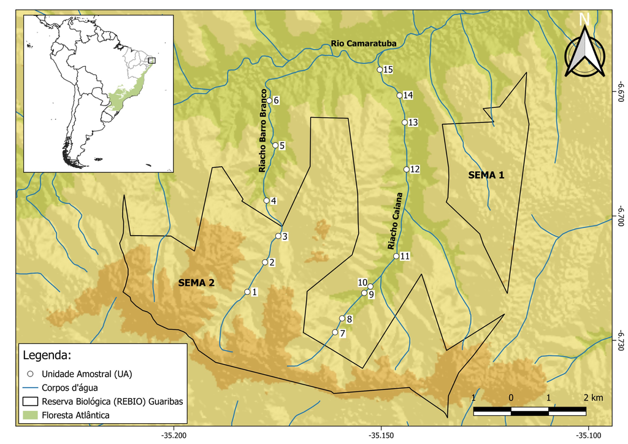

Figure 1: Localização das unidades amostrais.

## Tables

**Tab.: Tabela de dados ambientais**

Table 1: Tabela de dados ambientais.

| Variável | Ponto 1* | Ponto 2 | Ponto 3 | Ponto 4 | Ponto 5 | Ponto 6 | Ponto 7 | Ponto 8 | Ponto 9 | Ponto 10 | Ponto 11 | Ponto 12 | Ponto 13 | Ponto 14 | Ponto 15 |
| --- | --- | --- | --- | --- | --- | --- | --- | --- | --- | --- | --- | --- | --- | --- | --- |
| Tipo | I | I | II | IV | III | IV | III | III | III | IV | IV | IV | IV | III | IV |
| Qualidade da água |  |  |  |  |  |  |  |  |  |  |  |  |  |  |  |
| Condutividade (µS/cm) | 137,5 (119,2-164,4) | 148 (134,1-156,8) | 137,5 (98,3-160,2) | 154,2 (141,6-161,8) | 148,2 (120,8-165,5) | 140,7 (105-157,9) | 111,7 (85,2-129,8) | 98,8 (78,3-122,4) | 139,4 (92,2-184,2) | 223 (172,5-250,8) | 153,5 (109,3-212,5) | 123,4 (110,9-130,6) | 121,1 (100,8-136,6) | 130,9 (123,7-139,7) | 134,2 (125,6-139,6) |
| Turbidez (NTU) | 5 (2-10,7) | 4,9 (2,1-14,1) | 4,9 (1,5-9,2) | 5,7 (4-6,8) | 15,1 (11-17,7) | 21,5 (10-34,8) | 79,2 (2-346) | 11,7 (2-21) | 27,8 (7-44) | 11,7 (6-21) | 11,3 (5-20) | 32 (11,9-61) | 30,1 (9,3-64) | 10,2 (4,3-14) | 11,2 (8-14,2) |
| pH | 5,9 (4,7-7,5) | 5,7 (4,6-7,7) | 5,1 (4,5-6) | 5,5 (5-6) | 6 (5,3-6,6) | 6,1 (5,3-7,3) | 5,8 (5,3-6,4) | 5,9 (5,5-6,2) | 6,1 (6-6,5) | 6,3 (6-6,6) | 6,5 (6,2-6,9) | 6,4 (6,3-6,6) | 6,5 (6-6,8) | 6,7 (6,4-7) | 6,9 (6,7-7,4) |
| Morfologia |  |  |  |  |  |  |  |  |  |  |  |  |  |  |  |
| Elevação (m) | 107,1 (107,1-107,1) | 112,8 (112,8-112,8) | 89 (89-89) | 89,1 (89,1-89,1) | 71 (71-71) | 41,5 (41,5-41,5) | 80 (80-80) | 87 (87-87) | 76 (76-76) | 86 (86-86) | 76 (76-76) | 49 (49-49) | 47 (47-47) | 54 (54-54) | 49 (49-49) |
| Velocidade da água (m/s) | 0,073 (0,025-0,161) | 0,086 (0,035-0,24) | 0,135 (0,022-0,207) | 0,036 (0-0,115) | 0,261 (0,172-0,348) | 0,04 (0-0,119) | 0,271 (0,055-0,588) | 0,254 (0,021-0,423) | 0,296 (0,047-0,461) | 0,195 (0,09-0,302) | 0 (0-0) | 0,272 (0,084-0,508) | 0,118 (0,054-0,182) | 0,41 (0,33-0,557) | 0,22 (0,115-0,37) |
| Declividade | 1,4 (1-2) | 2,7 (2,5-3) | 2,4 (1,5-3) | 1,5 (1-2) | 2,1 (1,5-3) | 1,2 (1-2) | 1,3 (1-2) | 1,8 (1-2) | 3,2 (2,5-3,5) | 2,3 (1,5-2,5) | 1 (1-1) | 2,1 (1-3,5) | 1 (1-1) | 2,4 (2-3,5) | 1,9 (1,5-3) |
| Profundidade média (cm) | 12,8 (9-14) | 23,7 (16,3-31,7) | 23,8 (16-41) | 43,3 (28,3-51,3) | 22,1 (15-29) | 35,2 (25,3-40,7) | 13,2 (5,3-22,7) | 22,6 (10,3-36,3) | 19,8 (10,7-40,7) | 17,2 (10,7-26) | 33 (14-42) | 54,4 (15,7-98,7) | 49,9 (18-65) | 46,2 (34,7-64) | 72,4 (43-110) |
| Largura (m) | 6,2 (3,6-14,1) | 4,3 (0,7-9,2) | 2 (1,1-3,2) | 7,6 (2-16) | 1,7 (0,8-2,5) | 7,6 (4,9-10,2) | 1,1 (0,2-1,9) | 2 (0,9-3,7) | 3,1 (1-6,7) | 1,1 (0,6-1,3) | 11 (0-26,5) | 4,9 (3,4-5,8) | 19,5 (5,3-34,6) | 2,4 (1,4-3,3) | 3,2 (2,3-5,3) |
| Composição do substrato (%) |  |  |  |  |  |  |  |  |  |  |  |  |  |  |  |
| Lama | 100 (100-100) | 100 (100-100) | 95 (90-100) | 74,2 (5-100) | 38,3 (5-80) | 36,7 (10-100) | 90 (90-90) | 61,7 (10-90) | 7,5 (0-30) | 7,5 (0-10) | 83,3 (0-100) | 97,5 (90-100) | 68,3 (5-100) | 1,7 (0-5) | 66,7 (5-100) |
| Areia | 0 (0-0) | 0 (0-0) | 5 (0-10) | 25,8 (0-95) | 61,7 (20-95) | 63,3 (0-90) | 10 (10-10) | 38,3 (10-90) | 91,7 (70-100) | 90,8 (80-100) | 16,7 (0-100) | 0,8 (0-5) | 30 (0-95) | 98,3 (95-100) | 33,3 (0-95) |
| Cascalho fino | 0 (0-0) | 0 (0-0) | 0 (0-0) | 0 (0-0) | 0 (0-0) | 0 (0-0) | 0 (0-0) | 0 (0-0) | 0,8 (0-5) | 1,7 (0-10) | 0 (0-0) | 0 (0-0) | 1,7 (0-10) | 0 (0-0) | 0 (0-0) |
| Rochas | 0 (0-0) | 0 (0-0) | 0 (0-0) | 0 (0-0) | 0 (0-0) | 0 (0-0) | 0 (0-0) | 0 (0-0) | 0 (0-0) | 0 (0-0) | 0 (0-0) | 1,7 (0-10) | 0 (0-0) | 0 (0-0) | 0 (0-0) |
| Estrutura do habitat (%) |  |  |  |  |  |  |  |  |  |  |  |  |  |  |  |
| Macrófitas | 5,8 (5-10) | 10 (0-30) | 0 (0-0) | 17,9 (0-60) | 0 (0-0) | 1,7 (0-5) | 0 (0-0) | 0,8 (0-5) | 0 (0-0) | 0 (0-0) | 20,8 (0-50) | 0 (0-0) | 4,2 (0-15) | 0 (0-0) | 0 (0-0) |
| Gramíneas | 3,3 (0-10) | 8,3 (5-15) | 6 (0-15) | 27,1 (15-50) | 0 (0-0) | 21,8 (1-50) | 0 (0-0) | 0 (0-0) | 0 (0-0) | 0,8 (0-5) | 39,2 (15-50) | 5,8 (5-10) | 4,2 (0-10) | 0 (0-0) | 0 (0-0) |
| Vegetação submersa | 7,5 (5-15) | 8,3 (5-15) | 5,8 (0-10) | 5,8 (0-10) | 10,8 (0-20) | 5 (0-10) | 1,7 (0-5) | 6,7 (0-15) | 5 (0-15) | 0 (0-0) | 16,7 (5-20) | 10 (5-15) | 10 (0-20) | 0,8 (0-5) | 8,3 (0-25) |
| Cobertura vegetal | 68,3 (40-90) | 70,8 (50-85) | 76,7 (60-90) | 31,7 (25-50) | 70 (60-80) | 5 (0-20) | 83,3 (75-90) | 63,3 (30-80) | 65,8 (50-85) | 50 (40-70) | 0,8 (0-5) | 20,8 (10-30) | 33,3 (0-70) | 61,7 (50-70) | 61,7 (40-80) |
| Liteira | 7,5 (5-10) | 11 (1-25) | 15,8 (5-30) | 18,3 (10-30) | 10,2 (1-30) | 3,5 (0-10) | 7,5 (5-15) | 6,7 (5-10) | 5 (5-5) | 7,5 (5-10) | 1,7 (0-5) | 2,5 (0-5) | 5 (0-10) | 4,2 (0-5) | 8,3 (0-15) |
| Massas de raízes | 5 (0-15) | 10,8 (5-15) | 12,5 (5-20) | 4,2 (0-10) | 42,5 (5-90) | 3,3 (0-10) | 5,8 (0-10) | 10 (5-15) | 11,7 (5-20) | 9,2 (0-25) | 0,8 (0-5) | 10,8 (5-15) | 5,8 (0-15) | 7,5 (5-15) | 11,7 (10-15) |
| Algas | 2,5 (0-5) | 0,2 (0-1) | 5,5 (0-21) | 19,2 (15-25) | 0 (0-0) | 0,8 (0-5) | 0,8 (0-5) | 0 (0-0) | 0 (0-0) | 0 (0-0) | 0 (0-0) | 0 (0-0) | 0 (0-0) | 0 (0-0) | 0 (0-0) |
| Detritos | 30,8 (20-45) | 12,7 (5-20) | 17,7 (5-30) | 21,7 (5-35) | 16,8 (1-40) | 8,3 (0-20) | 22,2 (8-40) | 25,8 (10-40) | 23,3 (10-30) | 18,3 (10-40) | 4,2 (0-10) | 25,8 (0-45) | 20 (0-35) | 4,2 (0-15) | 17,5 (5-25) |

# Non-used figures and tables

**Non-used codes**

**non-used code**

```r
table(1:10)
```